# Economic and Health Impact of Weather Events Across US

# Synopsis

Storms and other severe weather events can cause both public health and economic problems for communities and municipalities. For instance, many severe events can result in fatalities, injuries, and property damage, and preventing such outcomes to the extent possible is a key concern.

This project involves exploring the U.S. National Oceanic and Atmospheric Administration’s (NOAA) storm database. This database tracks characteristics of major storms and weather events in the United States, including when and where they occur, as well as estimates of any fatalities, injuries, and property damage.

# Data Processing

The analysis is performed on [Storm Events Database](https://www.ncdc.noaa.gov/stormevents/ftp.jsp), provided by [National Climatic Data Center](https://www.ncdc.noaa.gov/). The data is from a comma-separated-value file available [here](https://d396qusza40orc.cloudfront.net/repdata%2Fdata%2FStormData.csv.bz2). There is also some documentation of the data available [here](https://d396qusza40orc.cloudfront.net/repdata%2Fpeer2_doc%2Fpd01016005curr.pdf).

To conduct the analysis the following steps are performed:

- Read and preprocess the data. Give a specific format to events with types Frost/Freeze, FROST/FREEZE and FROST\FREEZE which refer to the same type of event.

```r
data <- read.csv('data/repdata%2Fdata%2FStormData.csv')
```

- look at the number of unique event types:

```r
length(unique(data$EVTYPE))
```

```
## [1] 985
```

- change uppercase letters to lowercase:

```r
event_types <- tolower(data$EVTYPE)
```

- replace all punct. characters with a space and update the dataframe:

```r
event_types <- gsub("[[:blank:][:punct:]+]", " ", event_types)
length(unique(event_types))
```

```
## [1] 874
```

```r
data$EVTYPE <- event_types
```

This analysis focuses on two major events. First, it takes into account the dangerous events with respect to Population health. Second, the economic effects of weather events are analysed.

# Events related to Population Health

- the number of casualties are aggregated by the event type to find the events that are most harmful to population health

```r
library(plyr)
casualties <- ddply(data, .(EVTYPE), summarize,
                    fatalities = sum(FATALITIES),
                    injuries = sum(INJURIES))
```

- Find events that caused most death and injury

```r
fatal_events <- head(casualties[order(casualties$fatalities, decreasing = T), ], 5)

injury_events <- head(casualties[order(casualties$injuries, decreasing = T), ], 5)
```

The top 5 events that caused largest number of deaths are:

```r
fatal_events[, c("EVTYPE", "fatalities")]
```

```
##             EVTYPE fatalities
## 741        tornado       5633
## 116 excessive heat       1903
## 138    flash flood        978
## 240           heat        937
## 410      lightning        816
```

The top 5 events that caused most number of injuries are

```r
injury_events[, c("EVTYPE", "injuries")]
```

```
##             EVTYPE injuries
## 741        tornado    91346
## 762      tstm wind     6957
## 154          flood     6789
## 116 excessive heat     6525
## 410      lightning     5230
```

# Weather Events with considerable impact on the economy

The impact of weather events on the economy is anaysed by using the property damage and crop damage reportings/estimates.

- First,the property and crop damage for each event is analysed:

```r
exp_transform <- function(e) {
    # h -> hundred, k -> thousand, m -> million, b -> billion
    if (e %in% c('h', 'H'))
        return(2)
    else if (e %in% c('k', 'K'))
        return(3)
    else if (e %in% c('m', 'M'))
        return(6)
    else if (e %in% c('b', 'B'))
        return(9)
    else if (!is.na(as.numeric(e))) # if a digit
        return(as.numeric(e))
    else if (e %in% c('', '-', '?', '+'))
        return(0)
    else {
        stop("Invalid exponent value.")
    }
}
```

```r
prop_dmg_exp <- sapply(data$PROPDMGEXP, FUN=exp_transform)
data$prop_dmg <- data$PROPDMG * (10 ** prop_dmg_exp)
crop_dmg_exp <- sapply(data$CROPDMGEXP, FUN=exp_transform)
data$crop_dmg <- data$CROPDMG * (10 ** crop_dmg_exp)
```

- Second, Compute the economic loss by event type:

```r
library(plyr)
econ_loss <- ddply(data, .(EVTYPE), summarize,
                   prop_dmg = sum(prop_dmg),
                   crop_dmg = sum(crop_dmg))
```

- Third, filter out events that caused no economic loss:

```r
econ_loss <- econ_loss[(econ_loss$prop_dmg > 0 | econ_loss$crop_dmg > 0), ]
prop_dmg_events <- head(econ_loss[order(econ_loss$prop_dmg, decreasing = T), ], 5)
crop_dmg_events <- head(econ_loss[order(econ_loss$crop_dmg, decreasing = T), ], 5)
```

The top 5 events that caused most property damage are the following:

```r
prop_dmg_events[, c("EVTYPE", "prop_dmg")]
```

```
##                 EVTYPE     prop_dmg
## 138        flash flood 6.820237e+13
## 697 thunderstorm winds 2.086532e+13
## 741            tornado 1.078951e+12
## 209               hail 3.157558e+11
## 410          lightning 1.729433e+11
```

The top 5 events that caused biggest crop damage are the following:

```r
crop_dmg_events[, c("EVTYPE", "crop_dmg")]
```

```
##          EVTYPE    crop_dmg
## 84      drought 13972566000
## 154       flood  5661968450
## 519 river flood  5029459000
## 382   ice storm  5022113500
## 209        hail  3025974480
```

# Results

1. Health impact of weather events
- The following plot shows the top deadly events in US in the period 1950-2011:

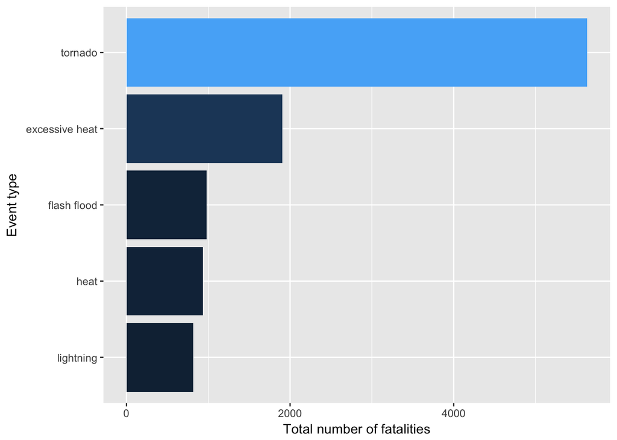

```r
library(ggplot2)

p1 <- ggplot(data=fatal_events,
             aes(x=reorder(EVTYPE, fatalities), y=fatalities, fill=fatalities)) +
    geom_bar(stat="identity") +
    coord_flip() +
    ylab("Total number of fatalities") +
    xlab("Event type") +
    theme(legend.position="none")

p2 <- ggplot(data=injury_events,
             aes(x=reorder(EVTYPE, injuries), y=injuries, fill=injuries)) +
    geom_bar(stat="identity") +
    coord_flip() +
    ylab("Total number of injuries") +
    xlab("Event type") +
    theme(legend.position="none")

par(mfrow=c(2,1))
plot(p1)
```

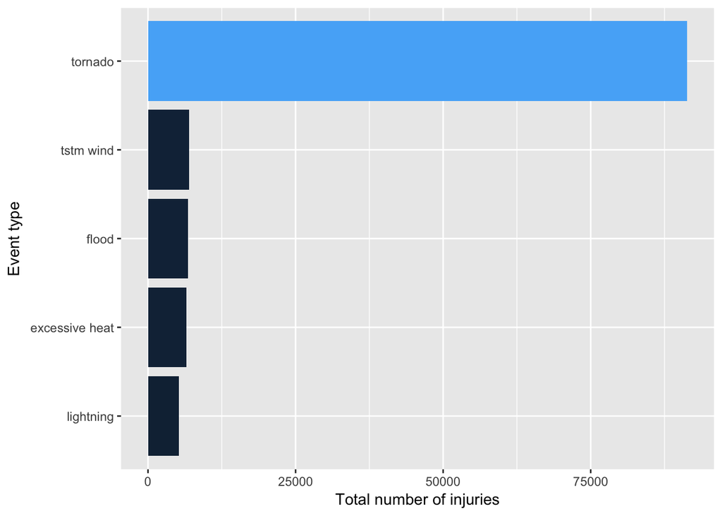

```r
plot(p2)
```

2. Economic impact of weather events
- The following plots show the weather cost to the US economy during the period 1950-2011:

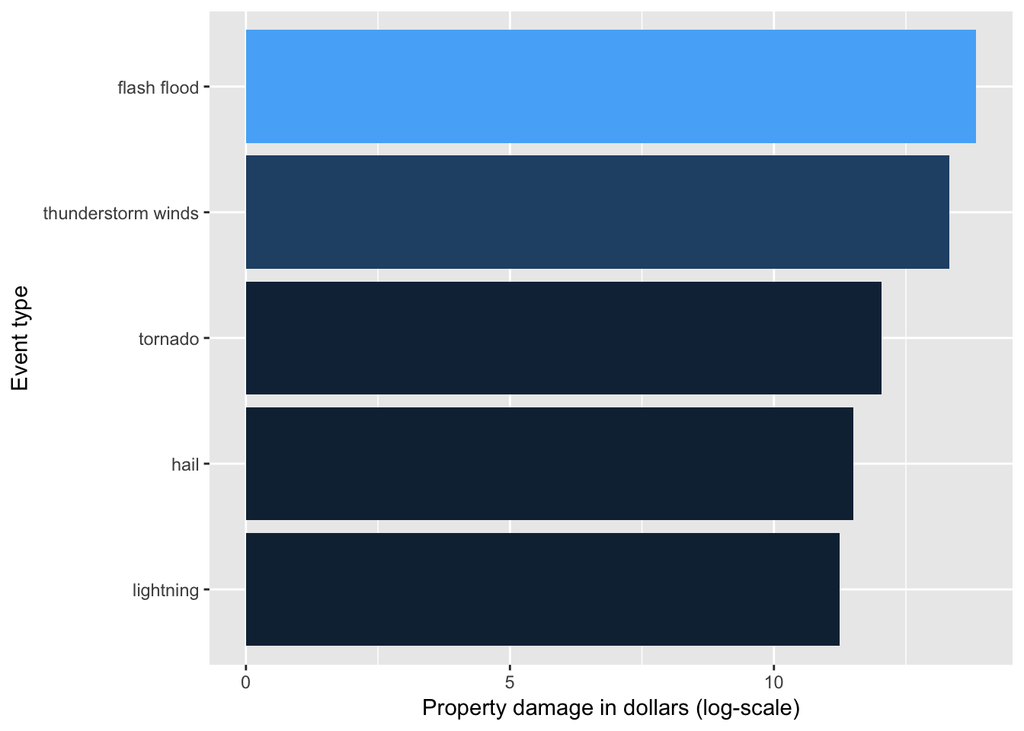

```r
library(ggplot2)

p1 <- ggplot(data=prop_dmg_events,
             aes(x=reorder(EVTYPE, prop_dmg), y=log10(prop_dmg), fill=prop_dmg )) +
    geom_bar(stat="identity") +
    coord_flip() +
    xlab("Event type") +
    ylab("Property damage in dollars (log-scale)") +
    theme(legend.position="none")

p2 <- ggplot(data=crop_dmg_events,
             aes(x=reorder(EVTYPE, crop_dmg), y=crop_dmg, fill=crop_dmg)) +
    geom_bar(stat="identity") +
    coord_flip() +
    xlab("Event type") +
    ylab("Crop damage in dollars") +
    theme(legend.position="none")

par(mfrow=c(2,1))
plot(p1)
```

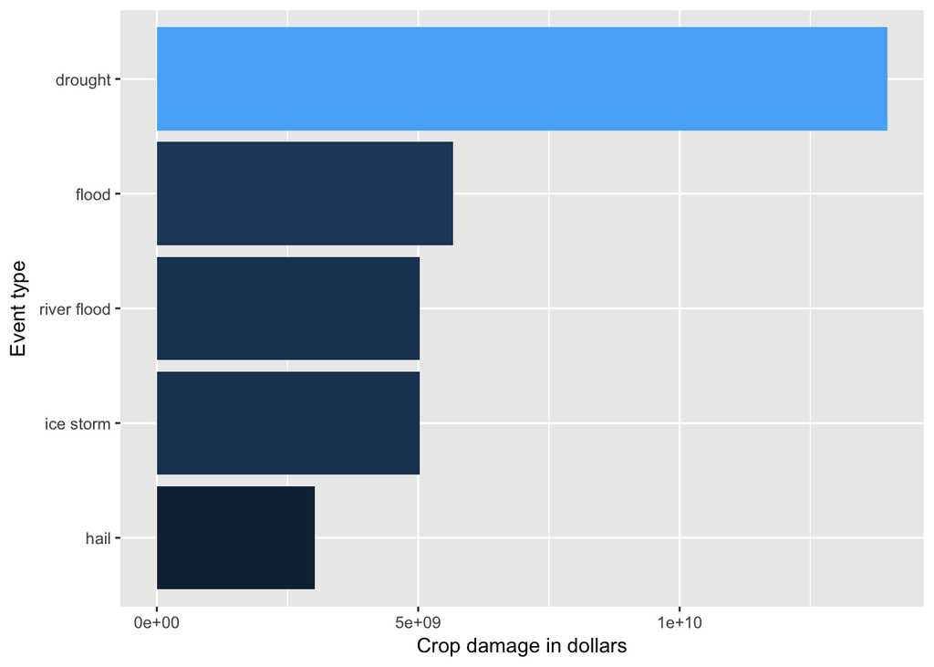

```r
plot(p2)
```

From the above figures, we can see that flash floods and thunderstorm winds cost the largest property damages among weather-related natural diseasters. The most severe weather event in terms of crop damage is the drought.

Note that property damages are given in logarithmic scale due to large range of values.